# Fire Blog

Marc Los Huertos

9/25/2018

## Ants and Fire

These data were collected to determine the impact of fire on ant in forests and a field (grassland).

```r
#Data input
forest <- c(9,6,4,6,7,10)
field <- c(12,9,12,10)

forest
```

```
## [1]  9  6  4  6  7 10
```

```r
field
```

```
## [1] 12  9 12 10
```

Now let’s explore the data with a histogram…

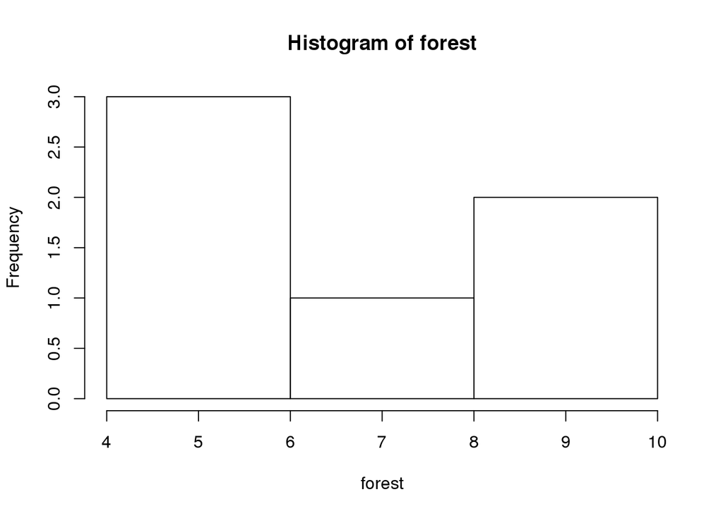

```r
hist(forest)
```

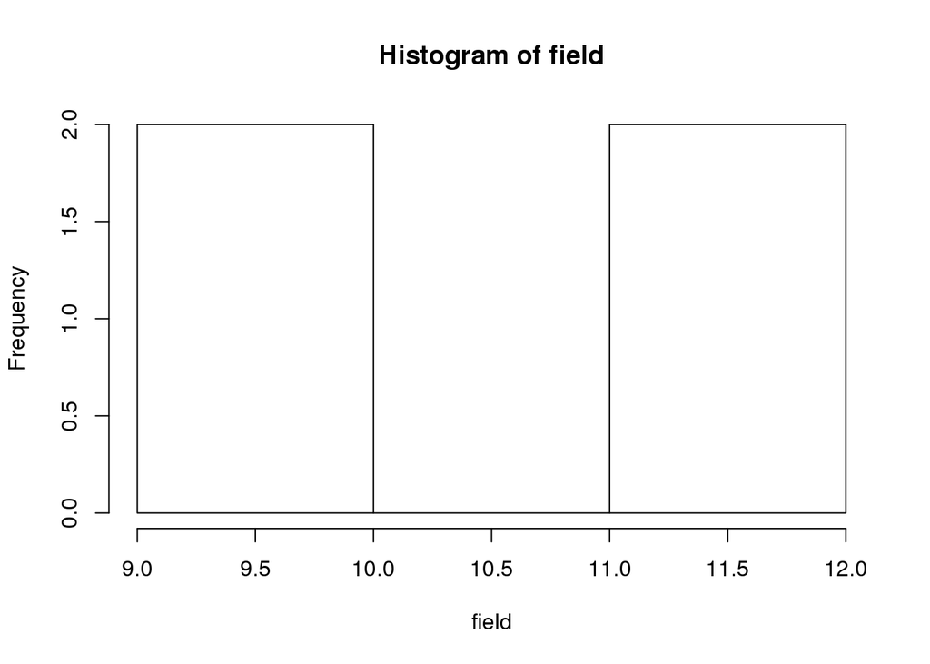

```r
hist(field)
```

Note: Does this look like a normal distribution

What’s the difference in the means? How do we know if these are signficant?

```r
mean(forest) - mean(field)
```

```
## [1] -3.75
```

Now, let’s create a data frame with the data – this form of data is useful for more complex analyses.

```r
df <- data.frame(id=seq(1, 10, 1),
              Habitat=c(rep("Forest", 6),rep("Field", 4)),
              Colonies=c(forest, field)
              )

df
```

```
##    id Habitat Colonies
## 1   1  Forest        9
## 2   2  Forest        6
## 3   3  Forest        4
## 4   4  Forest        6
## 5   5  Forest        7
## 6   6  Forest       10
## 7   7   Field       12
## 8   8   Field        9
## 9   9   Field       12
## 10 10   Field       10
```

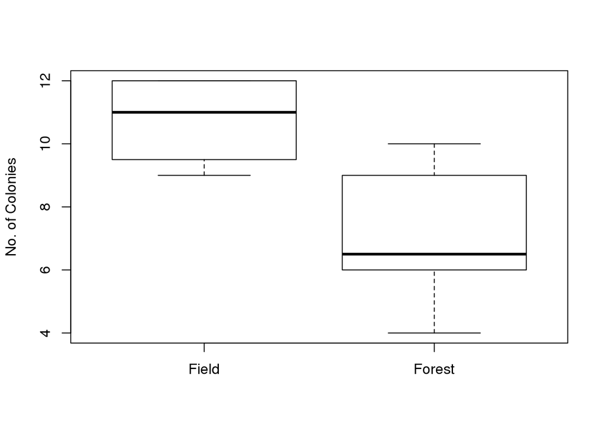

```r
boxplot(Colonies~Habitat, data=df, ylab="No. of Colonies")
```